# Measures of Portfolio Risk

What is portfolio risk?

When you invest your money into assets such as stocks and bonds, you're taking on risk. You don't know what the value of your investment will be in 20 years, next year, or even next month. Different portfolios can have varying levels of risk. For example, portfolios that are heavily weighted towards bonds usually have less risk than those weighted towards US equities. How can we confirm this? We can use different equations to measure a portfolio's risk. What would be a good equation to measure this risk?

**Standard deviation**

In Modern portfolio theory, developed by Nobel prize-winning economist Harry Markowitz, risk is measure using the annualized standard deviation of the portfolio's returns. $\sigma = \sqrt{\frac{\Sigma (r_i - \bar{r})}{N}}$. Is this a good measure of risk? It would certainly be a better measure of risk if a portfolio's returns were normally distributed. In practice, they are usually negatively skewed. Another downside is that investors are less concerned about variance among positive returns than variance among negative returns. This measure of risk is indifferent to that concern. This risk measure is used in the Sharpe ratio.

**Downside risk**

In Post-modern portfolio theory, the measure of risk used is called downside risk. Downside risk is the annualized standard deviation of returns that are below the investor's target return. You use the same formula as you did with the standard deviation, but only input returns that were less than your target returns. An improvement this measure makes is that it doesn't use variance among desired returns. If every few years a portfolio has a stellar performance of 20%+, well above a target return of 5%, those years' returns won't increasure your risk measure of the portfolio if you're measuring with downside risk. This risk measure is used in the Sortino Ratio.

**Kurtosis**

Kurtosis is a measure of the size of tails of a distribution. It is the fourth standardized moment: $\text{Kurt}[r] = \text{E}[(\frac{r-\bar{r}}{\sigma})^4] = \frac{\text{E}[(r-\bar{r})^4]}{(\text{E}[(r-\bar{r})^2])^2}$. A normal distribution has a kurtosis of 3. A larger kurtosis value indicates a larger tail. A larger tail indicates a larger probability of a significant loss. A realized significant loss can severely hamper the long-term growth of a portfolio.

**Maximum drawdown**

Maximum drawdown is the maximum observed percentage loss over a given period of time for a portfolio. This risk measure is used in the Calmar Ratio.

## Demo

Retrieve data from the SPY ETF, which tracks the S&P 500 index.

```python
import yfinance as yf
import pandas as pd
import numpy as np
import seaborn as sns
import matplotlib.pyplot as plt
%matplotlib inline

# Retrieve OHLC data for SPY from Dec 31, 1999 to August 31, 2020
spy = yf.Ticker('SPY')
prices = spy.history(start='1999-12-31', end='2020-08-31')
# Convert daily price data to daily returns
daily_r = prices['Close'].pct_change().dropna()
```

#### Visualize the total return over time

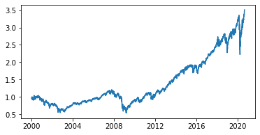

```python
fig, ax = plt.subplots(figsize=(6, 3))
ax.plot((1+daily_r).cumprod())
plt.show()
```

#### Calculate the annualized return

```python
def annualize_returns(r, periods_per_year):
    """
    r: series of returns
    periods_per_year: number of periods per year

    output: annualized returns
    """

    total_return = (1+r).prod()
    n_periods = r.shape[0]
    return total_return**(periods_per_year/n_periods)-1

r = annualize_returns(daily_r, 255)
print(f'Annualized return: {r}')
```

```
Annualized return: 0.06350268143467375
```

#### Calculate the annualized standard deviation of the returns

```python
def annualize_sd(r, periods_per_year):
    """
    r: series of returns
    periods_per_year: number of periods per year

    output: annualized returns
    """

    return r.std()*(periods_per_year**0.5)

sd = annualize_sd(daily_r, 255)
print(f'Standard deviation: {sd}')
```

```
Standard deviation: 0.2003828950016501
```

#### Calculate the downside risk of the returns if my annual target return is 5%

```python
# first find the annual returns
annual_returns = daily_r.groupby(daily_r.index.year).apply(annualize_returns, periods_per_year=255)

# find the standard deviation of annual returns that were below the target return
downside_risk = annual_returns[annual_returns < 0.05].std()
print(f'Downside risk: {downside_risk}')
```

```
Downside risk: 0.14102001723788932
```

#### Calculate the kurtosis of the annual returns

```python
def kurtosis(r):
    # https://en.wikipedia.org/wiki/Kurtosis
    demeaned_r = r - r.mean()
    # use population standard deviation (ddof=0)
    sigma = r.std(ddof=0)
    central_moment = (demeaned_r**4).mean()
    return central_moment/sigma**4

kurt = kurtosis(annual_returns)
print(f'Kurtosis: {kurt}')
```

```
Kurtosis: 3.2678999515055915
```

#### Visualize the annual return distribution

We can see that it has a fat tail on the negative side

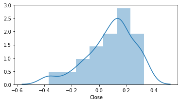

```python
fig, ax = plt.subplots(figsize=(6, 3))
sns.distplot(annual_returns, ax=ax)
plt.show()
```

#### Calculate the maximum drawdown

```python
def max_drawdown(r):
    total_r = (1+daily_r).cumprod()
    peaks = total_r.cummax()
    drawdowns = (total_r - peaks)/peaks
    return np.abs(np.amin(drawdowns))

mdd = max_drawdown(daily_r)
print(f'Max drawdown: {mdd}')
```

```
Max drawdown: 0.5518730791593994
```